# Elsa-analysis1

2023-09-27

# 1. Data pre-processing

## 1.1 General statistics

**Number of samples in total**

```
58
```

**Number of MAGs** The number of metagenome-assembled genomes (MAG) or draft bacterial genomes reconstructed from the metagenomic data.

```
555
```

**Amount of total data (GB):** The amount of total DNA data sequenced in gigabases (GB, one billion nucleotide bases).

```
333.71
```

**Amount of discarded data (GB):** The amount of data discarded due to low quality or lack of informativeness during data preprocesing. Discarding 5-15% of the produced data is within the expected range, due to formation of adaptor dimers, inclusion of adaptors in sequencing reads due to short insert sizes, low sequencing quality, etc.

```
10.37
```

**Amount of discarded data (in % of the raw data):**

```
3.11
```

**Amount of host data (GB):** The amount of data mapped against the host genome. The percentage refers to the amount of data mapped to the host genome respect to quality-filtered data. Note that this value can be very variable depending on the biological features of the sample (e.g., anal swabs contain more host DNA than faeces) and the employed reference genome (e.g., the chances for mapping to the genome are lower as the distance between) the study species and the employed reference genome differ).

```
6.49
```

**Amount of host data (% of the quality-filtered data):**

```
2.01
```

**Estimated prokaryotic data:** The amount and proportion of data belonging to prokayotic genomes respect to the total metagenomic fraction, as estimated from singleM analysis. Note that this is an estimation that relies on the genome sizes of genomes available in reference databases. If a given taxon is not properly represented, genome size estimations can be less accurate.

```
293.14
```

**Estimated prokaryotic data (% of the metagenomic data):**

```
92.51
```

```
316.85
```

**Amount of metagenomic data (% of the quality-filtered data):**

```
97.99
```

```
1860.26
```

**Total mapped sequencing depth (GB):**

```
266.02
```

```
32.07
```

**Average mapped sequencing depth (GB):**

```
4.59
```

## 1.2 MAG catalogue

### 1.2.1 Phylogenetic tree

The phylogenetic tree is constructed by placing the MAG sequences within the reference archaeal and bacterial trees using GTDBTK, followed by merging both trees.

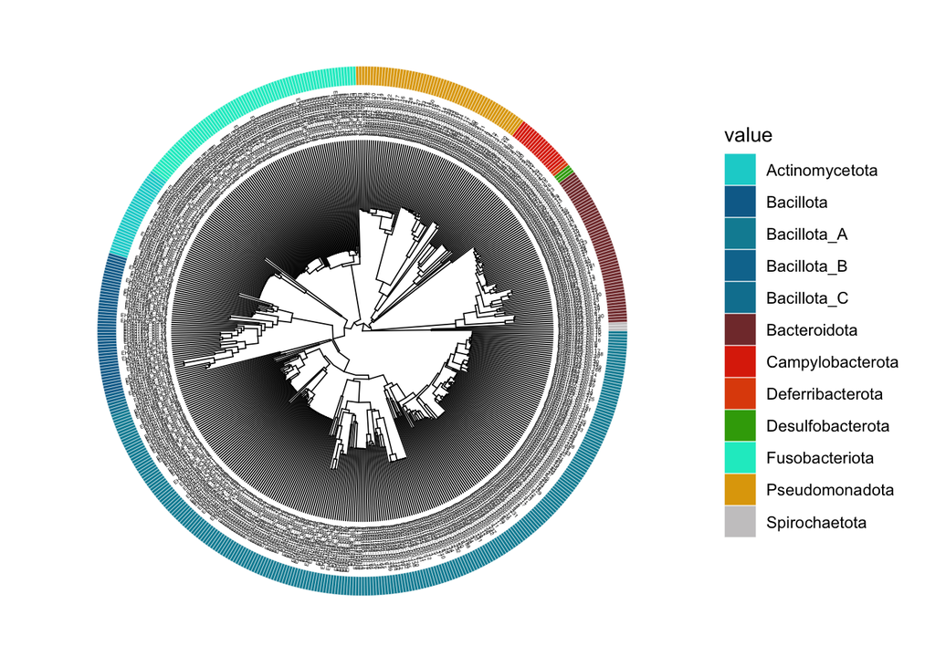

### 1.2.2 MAG details

Overview of the taxonomy and genome characteristics of the MAGs.  
**Completeness:** completeness of the MAG according to CheckM assessment.  
**Contamination:** contamination or redundancy of the MAG according to CheckM assessment.  
**Size:** size of the MAG in megabases (MB, one million nucleotide bases).

| Phylum | Completeness Mean | Completeness SD | Contamination Mean | Contamination SD | Size Mean | Size SD |
| --- | --- | --- | --- | --- | --- | --- |
| Actinomycetota | 75.06 | 14.05 | 3.31 | 2.48 | 1.38 | 0.30 |
| Bacillota | 88.01 | 15.12 | 1.64 | 2.16 | 1.89 | 0.58 |
| Bacillota_A | 77.72 | 16.57 | 2.88 | 2.87 | 1.95 | 0.65 |
| Bacillota_B | 87.24 | 15.67 | 0.89 | 1.15 | 1.91 | 0.25 |
| Bacillota_C | 95.57 | 8.80 | 0.28 | 0.20 | 1.96 | 0.27 |
| Bacteroidota | 83.04 | 18.85 | 2.28 | 2.98 | 2.70 | 0.88 |
| Campylobacterota | 89.41 | 16.84 | 0.74 | 1.50 | 1.73 | 0.34 |
| Deferribacterota | 96.72 | 0.05 | 0.62 | 0.06 | 2.30 | 0.05 |
| Desulfobacterota | 89.11 | 11.37 | 1.06 | 1.26 | 1.99 | 0.31 |
| Fusobacteriota | 67.48 | 14.12 | 4.26 | 2.71 | 1.41 | 0.53 |
| Pseudomonadota | 76.11 | 18.16 | 2.62 | 2.97 | 2.52 | 1.14 |
| Spirochaetota | 99.82 | 0.15 | 1.48 | 1.06 | 2.78 | 0.34 |

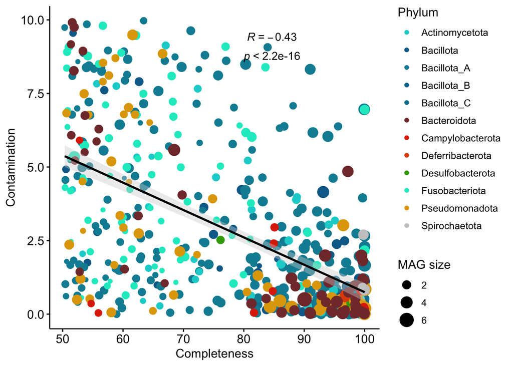

## 1.3 Sequencing depth assessment

In order to have representative results, the number of reads mapped to the MAG catalogue should be similar across samples. However, multiple reasons can create large imbalances, including uneven sequencing depth, different microbiome complexity across samples, different amount of host or non-microbial reads in the dataset, etc. The following plot shows the distribution of reads across samples.

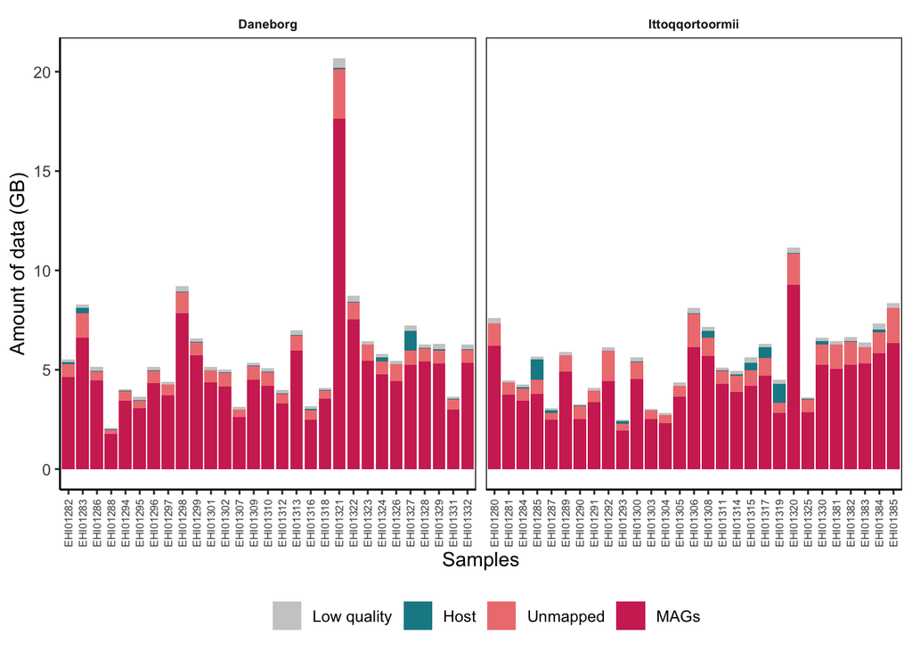

## 1.4 Minimum genome-coverage filtering

Mapping of sequencing reads against the reference genome catalogue is not perfect, and in consequence, all MAGs tend to get a few reads assigned. Implementing a minimum genome coverage filter aims at minimising artificial inflation of diversity due to this artifact of genome-resolved metagenomic analysis. However, if the sequencing depth is low and uneven across samples, this filtering can also introduce more distorsion.

## 1.5 Genome-size normalisation

Bacterial genomes can vary between 1 and 8 MB, which make relative representation of each genome dependent on its size. To account for genome size biases, read-counts can be normalised by applying a normalisation factor that modifies the read numbers according to the size of each genome compared to the average genome size in the dataset.

## 1.6 Count table

Once low-coverage genome counts have been filtered out, and the read counts have been normalised into genome counts, we can visualise the relative MAG abundances per sample. Note that the count scale is log-transformed.

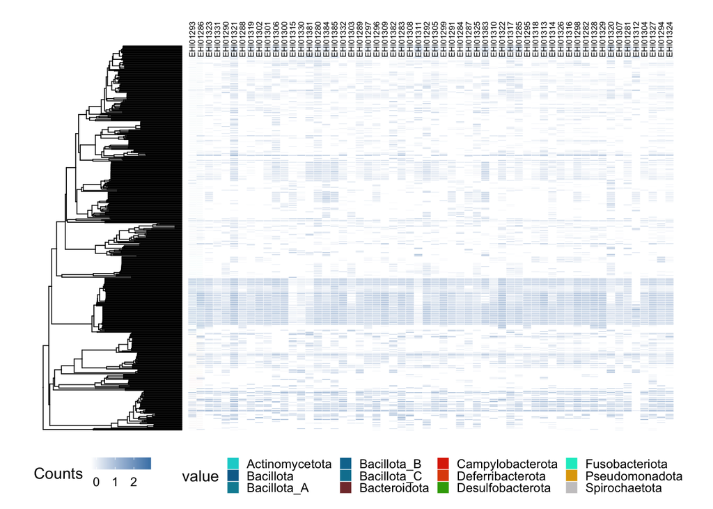

# 2. Taxonomic composition

Note that TSS normalisation simply divides each count value for the total count for the sample, thus transforming the data to 0-1 scale.

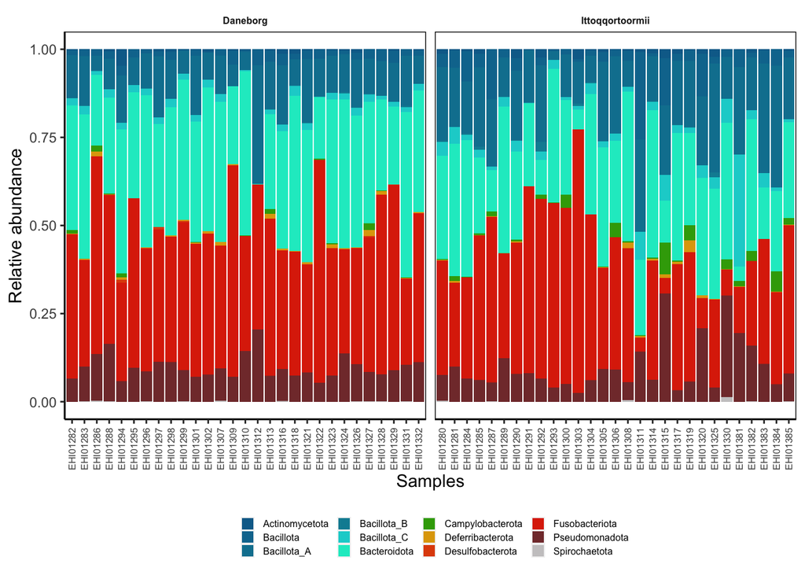

### Phylum percentages

```
           Phylum        Mean         SD
   Fusobacteriota 36.63617229 13.6021624
     Bacteroidota 30.34917323 11.1266820
      Bacillota_A 14.94367879  7.2293629
   Pseudomonadota  9.77735470  5.5151857
        Bacillota  3.31239049  4.0190706
      Bacillota_C  2.71325097  4.1839388
 Campylobacterota  0.89299322  1.6614731
   Actinomycetota  0.69779735  0.8750923
 Deferribacterota  0.39464909  0.5804386
      Bacillota_B  0.16437166  0.4243115
    Spirochaetota  0.06735096  0.1927730
 Desulfobacterota  0.05081724  0.1525258
```

# 3. Alpha diversity calculations

Diversity estimations for each sample.  
**Richness:** Number of MAGs per sample (after applying coverage filter).  
**Neutral diversity:** Hill number of q=1 (Shannon diversity), a diversity metric that accounts for richness and eveness (relative abundances) of the MAGs.  
**Phylogenetic diversity:** Phylogenetic Hill number of q=1, a diversity metric that accounts for richness and eveness (relative abundances), as well as phylogenetic relationships among MAGs.  
**Functional diversity:** Functional Hill number of q=1, a diversity metric that accounts for richness and eveness (relative abundances), as well as functional dissimilarities among MAGs.

```r
count_filtered <- column_to_rownames(count_table_cov_size_rel, "Genome")

metadata_unified <- read.csv("/Users/elsa/Desktop/THESIS/Thesis/metadata_unified.csv")
metadata_unified_clean <- metadata_unified %>%
  filter(sample != "")  # Filter rows where "sample" is not an empty string
selected_columns <- metadata_unified_clean %>%
  select(sample, Pack, PR_results_short, toxocaris_leonina, sarcocystis_spp, Tania_serialis, cryptosporidium, giardia, toxoplasma_gondii, trichincella_spp, Huldscore)

# This metadata object includes the selected additional columns, above
all_metadata <- left_join(metadata, selected_columns, by = "sample")
```

### Neutral

```r
# Calculate neutral alpha diversities using hilldiv2
alpha_div_neutral <- hilldiv(count_filtered, q=1)
```

#### Average neutral alpha diversities (q1)

```r
alpha_div_N <- t(alpha_div_neutral) %>%
  as.data.frame() %>%
  tibble::rownames_to_column("sample") %>%
  merge(., all_metadata, by="sample")

table_mean_alpha <- alpha_div_N %>%
  group_by(region) %>%
  summarise_at(.vars = names(.)[2],.funs = c(mean="mean", sd="sd"))
knitr::kable(table_mean_alpha, format = "html", full_width = F,col.names = c('Groups', 'Mean', 'SD'), digits = 3) %>%
  kable_styling(latex_options="scale_down")
```

| Groups | Mean | SD |
| --- | --- | --- |
| Daneborg | 102.846 | 20.952 |
| Ittoqqortoormii | 96.607 | 37.606 |

```r
alpha_div <- t(alpha_div_neutral) %>%
  as.data.frame() %>%
  rename( "Diversity" = "q1")  %>%
  rownames_to_column("sample") %>%
  left_join(sequence_fractions, by = join_by(sample == sample)) %>% #add sequencing depth information
  mutate(depth=round(mags_bases/1000000,3))
```

#### Correlations

[figure not shown]

```r
ggscatter(alpha_div, x = "mags_bases", y = "unmapped_bases", color="depth",
          add = "reg.line", conf.int = TRUE,  add.params = list(color = "gray", fill = "lightgray"),
          cor.coef = TRUE, cor.method = "kendall", size = "Diversity",
          cor.coeff.args = list(method = "kendall", label.x = 3e+9, label.sep = "\n"),
          xlab = "MAG bases", ylab = "Unmapped reads", legend="right") +
  guides(col=guide_legend("Depth"),
         size=guide_legend("Alpha diversity")) +
  font("legend.title", face = "bold")
```

#### Alpha diversity plots

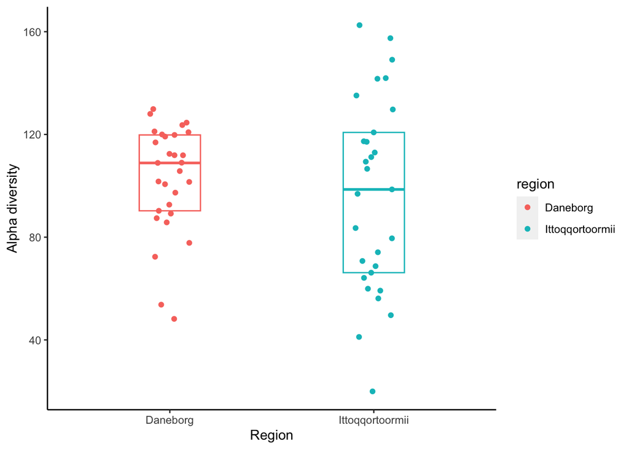

```r
# Create the plot for alpha_div_N
alpha_div_N %>%
  ggplot(aes(x = region, y = q1, group = region, color = region)) +
  geom_boxplot(alpha = 0.2, outlier.shape = NA, width = 0.3, show.legend = FALSE, coef = 0) +
  geom_jitter(width = 0.1, show.legend = TRUE) +
  theme(panel.background = element_blank(),
        panel.border = element_blank(),
        panel.grid.major = element_blank(),
        panel.grid.minor = element_blank(),
        axis.line = element_line(size = 0.5, linetype = "solid", colour = "black")) +
  xlab("Region") +
  ylab("Alpha diversity")
```

### Phylogenetic

```r
alpha_div_phylo <- hilldiv(data=count_filtered,tree=tree, q=1)
```

#### Average phylogenetic alpha diversities

```r
alpha_div_P <-  t(alpha_div_phylo) %>%
  as.data.frame() %>%
  tibble::rownames_to_column("sample") %>%
  merge(., all_metadata, by="sample")

table_mean_alpha_phylo <- alpha_div_P %>%
  group_by(region) %>%
  summarise_at(.vars = names(.)[2],.funs = c(mean="mean", sd="sd"))

knitr::kable(table_mean_alpha_phylo, format = "html", full_width = F,col.names = c('Groups', 'Mean', 'SD'), digits = 3) %>%
  kable_styling(latex_options="scale_down")
```

| Groups | Mean | SD |
| --- | --- | --- |
| Daneborg | 49.172 | 6.606 |
| Ittoqqortoormii | 51.802 | 13.178 |

#### Alpha diversity plots

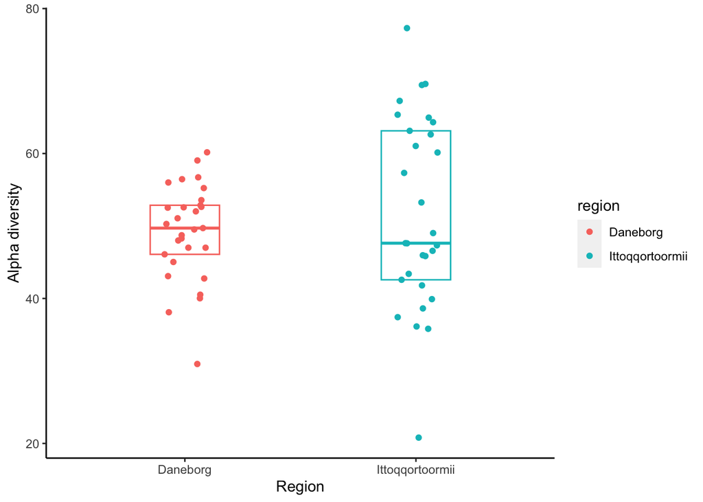

```r
alpha_div_P %>%
  ggplot(aes(x = region, y = q1, group = region, color = region)) +
  geom_boxplot(alpha = 0.2, outlier.shape = NA, width = 0.3, show.legend = FALSE, coef = 0) +
  geom_jitter(width = 0.1, show.legend = TRUE) +
  theme(panel.background = element_blank(),
        panel.border = element_blank(),
        panel.grid.major = element_blank(),
        panel.grid.minor = element_blank(),
        axis.line = element_line(size = 0.5, linetype = "solid", colour = "black")) +
  xlab("Region") +
  ylab("Alpha diversity")
```

### Neutral

```r
beta_div_neutral <- count_filtered %>%
    hillpair(., q = 1) #calculate neutral beta diversities and distance matrix
```

```r
#### NMDS

hill_pair_dis <- hillpair(data=count_filtered,q=1)
```

```
The estimated time for calculating the 1653 pairwise combinations is 3 seconds.
```

```r
# Generate NMDS ordination
hill_pair_dis_dist <- hill_pair_dis %>%
                select(first,second,C) %>% #based on dissimilarity metric C
                as.data.frame() %>%
        pivot_wider(names_from = first, values_from = C) %>%
                column_to_rownames(var = "second") %>%
                as.matrix() %>%
                as.dist()
hill_pair_dis_nmds <- metaMDS(hill_pair_dis_dist,trymax = 500, k=2, verbosity=FALSE) %>%
                vegan::scores() %>%
                as_tibble(., rownames = "sample")

#Add metadata
hill_pair_dis_nmds <- hill_pair_dis_nmds %>%
      left_join(all_metadata, by = join_by(sample == sample))
```

#### NMDS:

using script from https://github.com/anttonalberdi/hilldiv2

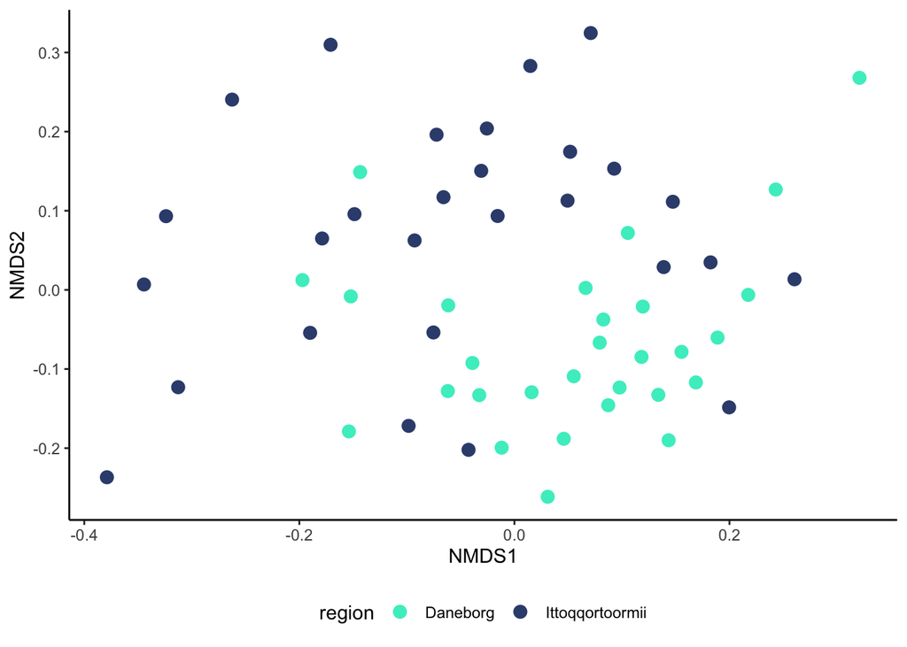

```r
#Plot ordination
ggplot(hill_pair_dis_nmds, aes(x=NMDS1,y=NMDS2, color=region)) +
        geom_point(size=3) +
        scale_color_manual(values = c("#46edc8","#374d7c")) +
        theme_classic() +
        theme(legend.position="bottom", legend.box="vertical")
```

using adapted original script

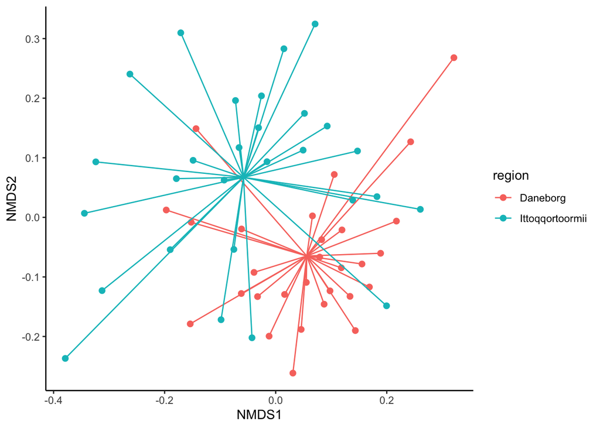

```r
NMDS.centroids_1=aggregate(hill_pair_dis_nmds[,c(2:3)],by=list(hill_pair_dis_nmds$region),FUN=mean)
colnames(NMDS.centroids_1) <- c("region","NMDS1","NMDS2")
hill_pair_dis_nmds=merge(hill_pair_dis_nmds,NMDS.centroids_1,by="region")

centroids <- hill_pair_dis_nmds  %>%
  group_by(region)  %>%
  summarize(NM1=mean(NMDS1.y), NM2=mean(NMDS2.y))

ggplot(hill_pair_dis_nmds, aes(x=NMDS1.x,y=NMDS2.x,colour=region)) +
  geom_point(aes(x=NMDS1.x,y=NMDS2.x),size=2) +
  geom_segment(aes(x=NMDS1.y, y=NMDS2.y, xend=NMDS1.x, yend=NMDS2.x))+
  theme(axis.line = element_line(colour = "grey"),
        panel.grid.major = element_blank(),
        panel.grid.minor = element_blank(),
        panel.border = element_blank(),
        panel.background = element_blank(),
        axis.title=element_blank(),
        legend.text=element_text(size=14))+
  # facet_wrap(~ factor(type))+
  theme_classic()+
  labs( x = "NMDS1", y = "NMDS2")
```

```r
# Permutation test
# ps.disper.neutral <- betadisper(hill_pair_dis_dist, all_metadata$region, type = c("median"), bias.adjust = FALSE, sqrt.dist = FALSE, add = FALSE)

# Error in pts[groups == i, , drop = FALSE] : (subscript) logical subscript too long

# permutest(ps.disper.neutral, pairwise = TRUE, permutations = 999) # cannot run due to error in ps.disper.neutral

# a p value of >0.05 in this case will tell you that the data is in an ok format for running an adonis
## results:

meta_order <- all_metadata[order(all_metadata$sample),]
m1 <- as.matrix(hill_pair_dis_dist)
metadata_ord<- all_metadata[order(match(all_metadata$sample,rownames(m1))),]
# this section correctly orders the metadata so that it matches to the beta diversity distance matrix

# Run test
# adonis2(hill_pair_dis_dist ~ region, data =metadata_ord, permutations = 999)
# this is essentially a MANOVA. a p value of <0.05 is significant. The R2 value will tell you what amount of variation is based off the clustering variable. in this case the region.

## results:
```